## Background

- Illegal crossing of the United States southern border has been a central topic of debate in the current political climate. The data are from the US Customs and Border Protection. It is of particular interest to note that the federal fiscal year 2017 saw a all-time low in apprehensions compared to the past 17 years.

# Data Comparsion

## Comparision of Each Sector by Month

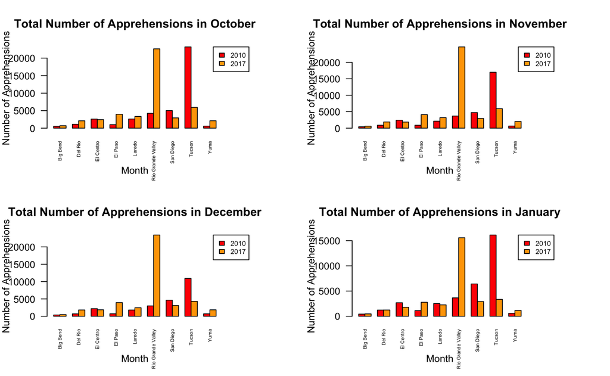

Comparsion of Data by Month (1)

## Comparsion of Each Sector by Month (Cont.)

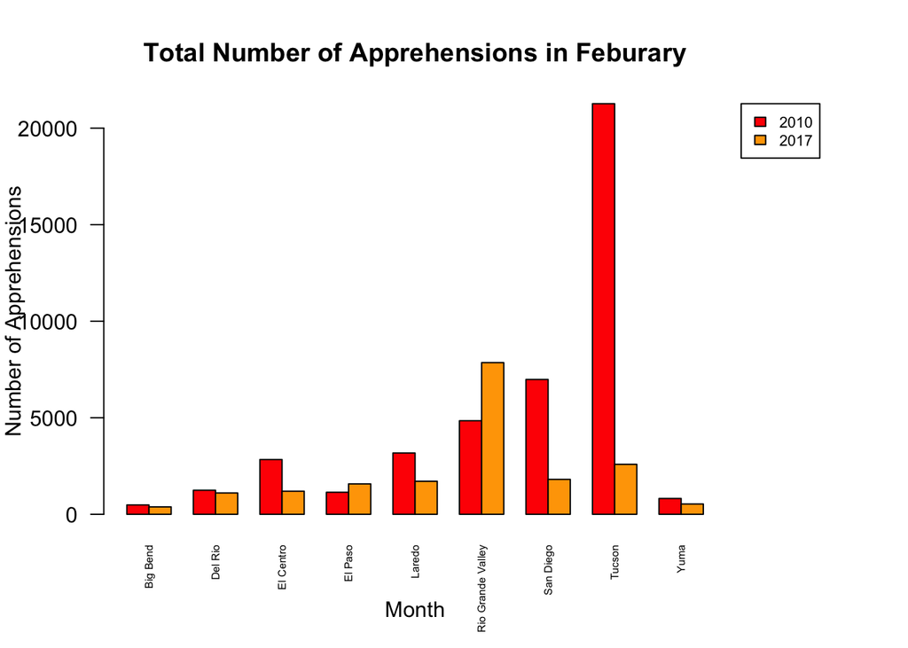

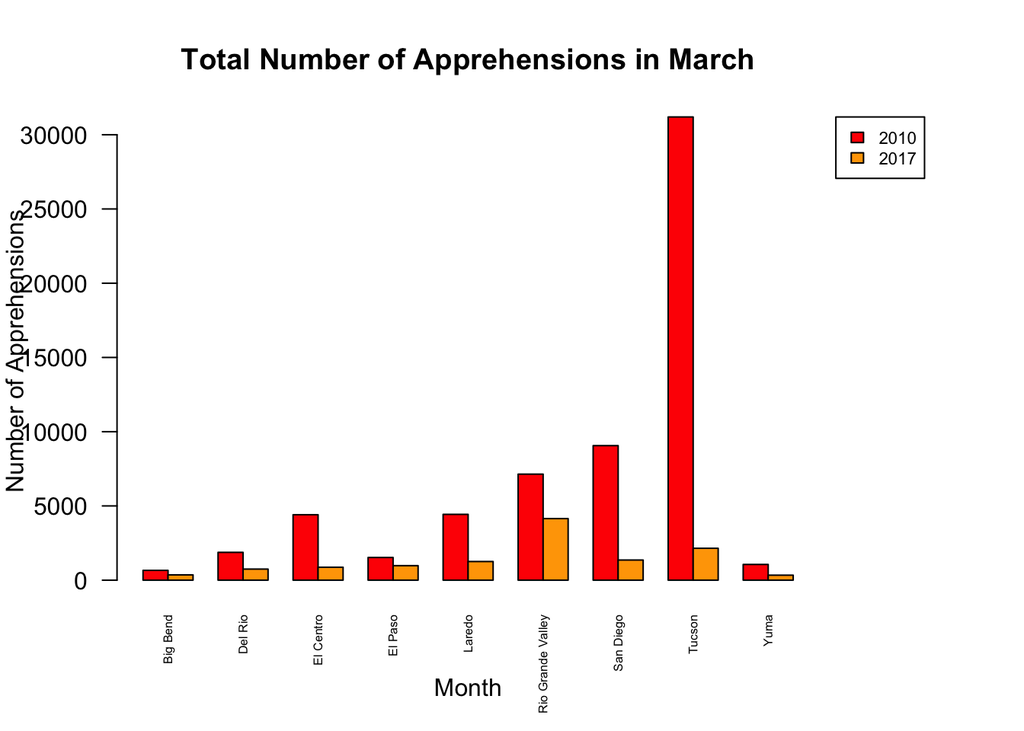

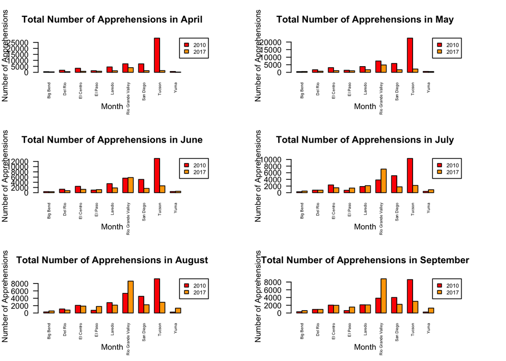

## Comparision of Each Month by Sector

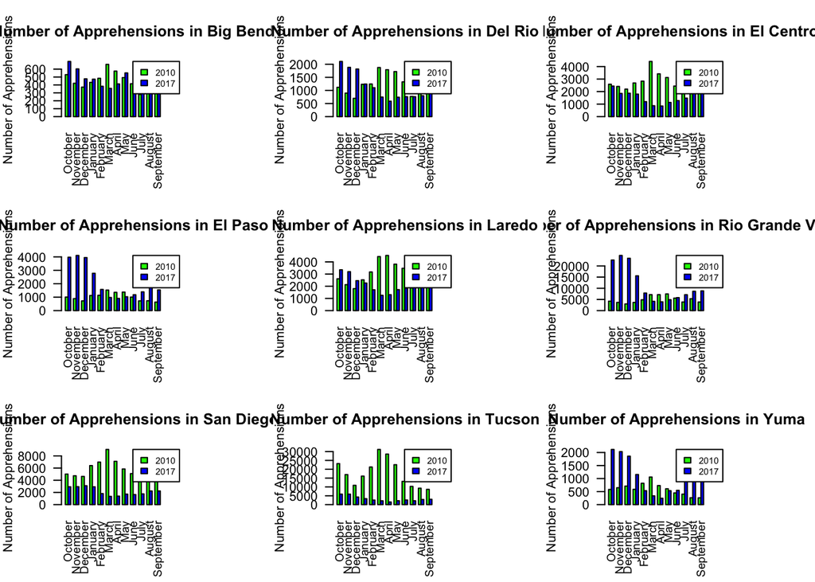

## Statistical Tests: Variance Test for One-month Period

$$H_0: \sigma^2_{Tucson} = \sigma^2_{Rio Grande Valley}$$
$$H_A: \sigma^2_{Tucson} \neq \sigma^2_{Rio Grande Valley}$$

```
##
##  F test to compare two variances
##
## data:  most[, 1] and most[, 2]
## F = 0.93205, num df = 11, denom df = 11, p-value = 0.9092
## alternative hypothesis: true ratio of variances is not equal to 1
## 95 percent confidence interval:
##  0.2683166 3.2376648
## sample estimates:
## ratio of variances
##           0.932051
```

We fail to reject the null hypothesis at $\alpha=0.05$ and conclude that the variances of Tucson and Rio Grande Valley are equal.

## Statistical Tests: Two Sample t-test for One-month Period

$$H_0: \mu_{Tucson} = \mu_{Rio Grande Valley}$$
$$H_A: \mu_{Tucson} \neq \mu_{Rio Grande Valley}$$

```
##
##  Two Sample t-test
##
## data:  most[, 1] and most[, 2]
## t = 1.9547, df = 22, p-value = 0.06344
## alternative hypothesis: true difference in means is not equal to 0
## 95 percent confidence interval:
##   -379.1203 12819.1203
## sample estimates:
## mean of x mean of y
##   17683.5   11463.5
```

We fail to reject the null hypothesis at $\alpha=0.05$ and conclude that there is no difference in mean apprehensions between Tucson in 2010 and Rio Grande Valley in 2017.

## Statistical Tests: Variance Test for Three-month Period

$$H_0: \sigma^2_{Mar-May} = \sigma^2_{Oct-Dec}$$
$$H_A: \sigma^2_{Mar-May} \neq \sigma^2_{Oct-Dec}$$

```
##
##  F test to compare two variances
##
## data:  max_three$max_2010 and max_three$max_2017
## F = 1.43, num df = 9, denom df = 9, p-value = 0.6027
## alternative hypothesis: true ratio of variances is not equal to 1
## 95 percent confidence interval:
##  0.3551856 5.7570716
## sample estimates:
## ratio of variances
##           1.429975
```

We fail to reject the null hypothesis at $\alpha=0.05$ and conclude that the variances of the three-month period Mar-May and of Oct-Dec are equal.

## Statistical Tests: Two Sample t-test for Three-month Period

$$H_0: \mu_{Mar-May} = \mu_{Oct-Dec}$$
$$H_A: \mu_{Mar-May} \neq \mu_{Oct-Dec}$$

```
##
##  Two Sample t-test
##
## data:  max_three$max_2010 and max_three$max_2017
## t = 0.25287, df = 18, p-value = 0.8032
## alternative hypothesis: true difference in means is not equal to 0
## 95 percent confidence interval:
##  -39459.94  50258.74
## sample estimates:
## mean of x mean of y
##   32728.6   27329.2
```

We fail to reject the null hypothesis at $\alpha=0.05$ and conclude that there is no difference in mean apprehensions between the three-month period of Mar-May in 2010 and of Oct-Dec in 2017.

## Time Series

In order to explore the claim that US border apprehensions are at an all-time low when compared to 17 years ago, a time series plot was used to graph long-term trend.

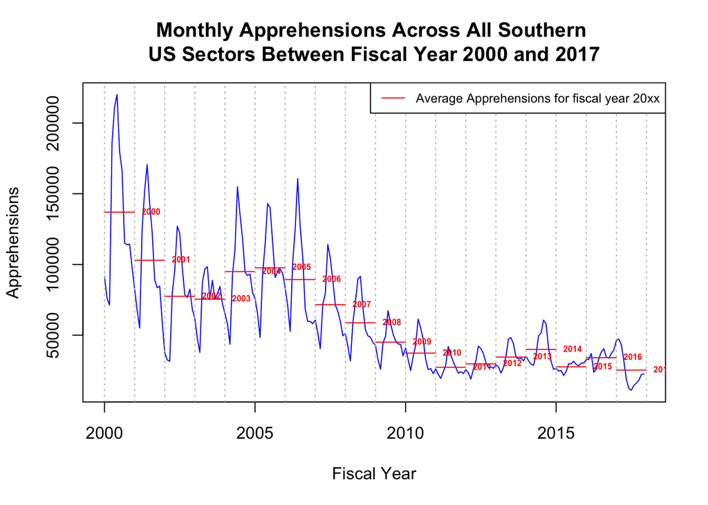

## Conclusion

Through the use of bar plots and statistical tests, we see that the trend has not changed significantly from 2010 to 2017. However, after looking at the trend over 17 years, it is evident that there has been a downward decline in border apprehensions from 2000 to 2017 and that the number of apprehensions in 2017 is at indeed an all-time low.